# Linear Chain Trick crash course

A quick guide to Linear Chain Trick

Author

Anh Phan

Published

April 3, 2025

**NoteBefore we dive in**

The goal of this blog post:

- Introduce Linear Chain Trick
- Explain Linear Chain Trick in a more “digestable” way (hopefully)

What this blog post does **NOT** provide:

- Detailed mathematical proof for Linear Chain Trick
- More advanced use cases (e.g., transition to multiple compartments)

Who is this for?

- Those who are relatively new to compartmental modeling (like me) but already know the basics (e.g., able to understand the SIR model)
- And, of course, those who are interested to learn and understand Linear Chain Trick

## Background

Traditionally, SIR model is formulated using the following ODE

$$\begin{cases}
\frac{dS}{dt} = - \beta \frac{I}{N} S \\
\frac{dI}{dt} = \beta \frac{I}{N} S - \gamma I \\
\frac{dR}{dt} = \gamma I
\end{cases}
\tag{1}$$

With the underlying assumption that the infectious period (time to move from I to R **or** dwell-time in I compartment) is exponentially distributed (with rate $\gamma$ and mean infectious time $\frac{1}{\gamma}$ ). This was proven to be inadequate to capture many disease dynamics, as such, several formulations were suggested to incorporate other types of distributions.

Linear Chain Trick (LCT) in particular, is for modeling **Erlang** distributed infectious period (i.e., Gamma distribution with integer shape).

## Linear Chain Trick

### Formulation

The generalized formulation for $I \rightarrow R$ transition where infectious period is Erlang distributed is as followed

$$\begin{cases}
\frac{dS}{dt} = - \beta \frac{I}{N} S \\
\frac{dI_1}{dt} = \beta \frac{I}{N} S - rI_1 \\
\frac{dI_2}{dt} = rI_1 - rI_2 \\
\vdots \\
\frac{dI_k}{dt} = rI_{k - 1} - rI_k \\
\frac{dR}{dt} = rI_k
\end{cases}
\tag{2}$$

Where:

- $k$ is the shape parameter of the Erlang distribution
- $r$ is the rate parameter of the Erlang distribution

**NoteExample**

For Erlang distribution with `rate=1/4`, `shape = 3`, the formulation would be

$$\begin{cases}
\frac{dS}{dt} = - \beta \frac{I}{N} S \\
\frac{dI_1}{dt} = \beta \frac{I}{N} S - rI_1 \\
\frac{dI_2}{dt} = \frac{1}{4}I_1 -\frac{1}{4}I_2 \\
\frac{dI_3}{dt} = \frac{1}{4}I_2 -\frac{1}{4}I_3 \\
\frac{dI_4}{dt} = \frac{1}{4}I_3
\end{cases}$$

**The intuition of what is going on**: The key idea is to delay the transition from I to R by introducing sub-compartment(s) i.e, $I_1$, $I_2$, …, $I_k$.

**NoteThe property behind LCT**

LCT works by exploiting a property of Poisson processes: the time to $k_{th}$ event under a homogeneous Poisson process at rate $r$ is Erlang distributed with shape $k$ and rate $r$ (Hurtado and Kirosingh 2019).

Another way to think of it is each event is preceded by a length of time that is exponentially distributed with rate $r$, and thus the time to $k_{th}$ event is the sum of $k$ independent and identical exponential random variables. The distribution of this sum turns out to be the Erlang distribution, with rate $r$ and shape $k$.

In the context of the example SIR model ( Equation 2 ), time to $k_{th}$ event is the time going from sub-compartment $I_1$ to $I_k$. The rate of transitioning from $I_n$ to $I_{n+1}$ is constant ($r$) which implies the time of transitioning is exponentially distributed.

### Implementing LCT

Consider a very simple scenario where there is no incoming population for I (i.e., no `S->I` transition) and the infectious period is Erlang distributed with `rate=1/4` and `shape (k) = 3`

**deSolve**

```r
library(deSolve)
library(tidyverse)

transition_func <- function(t, state, param){
  with(as.list( c(state, param) ), {
    dI1 = - rate*I1
    dI2 = rate*I1 - rate*I2
    dI3 = rate*I2 - rate*I3
    dR = rate*I3

    list(c(dI1, dI2, dI3, dR))
  })
}

desolveInitialValues <- c(
  I1 = 100,
  I2 = 0,
  I3 = 0,
  R = 0
)

# ====== settings ========
parameters <- c(
  rate = 1/4 # rate for Erlang distribution
)
```

```r
simulationDuration <- 50
times <- seq(0, simulationDuration)

ode_mod <- ode(y = desolveInitialValues, times = times, parms = parameters, func = transition_func)
ode_mod <- as.data.frame(ode_mod)
```

**odin**

```r
library(odin)

model_generator <- odin({
  deriv(I1) = - rate*I1
  deriv(I2) = rate*I1 - rate*I2
  deriv(I3) = rate*I2 - rate*I3
  deriv(R) = rate*I3

  init_I1 <- user(0)
  initial(I1) <- init_I1

  rate <- user(1/4)

  initial(I2) <- 0
  initial(I3) <- 0
  initial(R) <- 0
})
```

```r
simulationDuration <- 50
times <- seq(0, simulationDuration)

odin_mod <- model_generator$new(init_I1 = 100, rate = 1/4)
odin_mod <- odin_mod$run(times)
odin_mod <- as.data.frame(odin_mod)
```

## Visualization

Another good way to have an intuitive understanding is to visualize what is happening.

### Population in sub-compartments

The following plot shows how the population in each sub-compartment and the population of I (dashed line) changes over time. Note that we’re using the model from the previous section, with `Erlang(r=1/4, k=3)` distributed infectious period.

**Code for plotting**

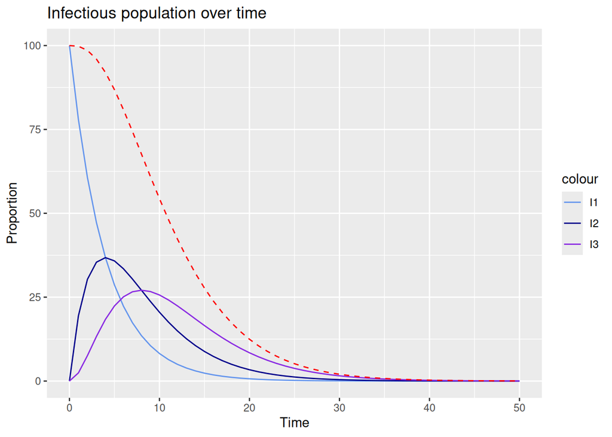

```r
i_plot <- ode_mod %>%
  mutate(
    I = I1 + I2 + I3
  ) %>%
  ggplot() +
    geom_line(aes(x = time, y = I1, color = "I1")) +
    geom_line(aes(x = time, y = I2, color = "I2")) +
    geom_line(aes(x = time, y = I3, color = "I3")) +
    geom_line(aes(x = time, y = I), color = "red", linetype = "dashed") +
    scale_color_manual(
      values = c("I1" = "cornflowerblue", "I2" = "darkblue", "I3" = "blueviolet")
    )+
    labs(
      title = "Infectious population over time",
      x = "Time",
      y = "Proportion"
    )
i_plot
```

**Looks familiar?** If not, here is the Erlang distribution with `rate = 1/4`, `shape=1, 2 and 3`

**Code for plotting**

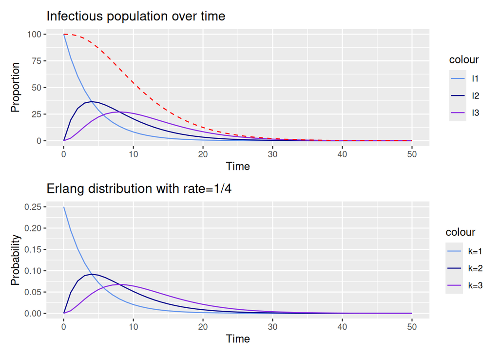

```r
library(patchwork)
gamma_dists <- data.frame(
    x = seq(0, 50),
    shape1 = dgamma(seq(0, 50), rate = 1/4, shape = 1),
    shape2 = dgamma(seq(0, 50), rate = 1/4, shape = 2),
    shape3 = dgamma(seq(0, 50), rate = 1/4, shape = 3)
  ) %>%
  ggplot() +
  geom_line(aes(x=x, y=shape1, color="k=1")) +
  geom_line(aes(x=x, y=shape2, color="k=2")) +
  geom_line(aes(x=x, y=shape3, color="k=3")) +
  scale_color_manual(
    values = c("k=1" = "cornflowerblue", "k=2" = "darkblue", "k=3" = "blueviolet")
  )+
  labs(
    x = "Time",
    y = "Probability",
    title = "Erlang distribution with rate=1/4"
  )

i_plot / gamma_dists
```

Visually, we can also see that the distribution for dwell-time of $I_n$ follows $Erlang(rate=r, shape=n)$ distribution. To change the shape parameter of the Erlang distribution, we can simply change the number of sub-compartments.

### Sum of k i.i.d. exponential random variables

One of the reason LCT works is the fact that “the sum of $k$ identical, independent exponential random variables with rate $r$ follows $\text{Erlang}(r,k)$ distribution”.

To visualize this, we can try computing distribution of sum using convolution and compare it with an Erlang distribution.

**Function to compute sum of k i.i.d. exp variables**

```r
compute_dist_sum_exp <- function(rate=1/2, k=2, n = 100){
  # divide by k so sum of k identical distribution can go up to n
  x_range <- seq(0, n/k, by=0.05)
  curr_density <- dexp(x_range, rate = rate)

  if(k>1){
    sapply(
      2:k,
      \(curr_k){
        # compute distribution of sum of 2 exponential random variable using convolution
        curr_density <<- convolve(
          curr_density,
          rev(dexp(x_range, rate = rate)),
          type = "open"
        )

        # adjust x_range for length of the convolution
        x_range <<- seq(0, n/k, length.out = length(curr_density))
      }
    )
  }

  data.frame(
    x = seq(0, n, length.out = length(curr_density)),
    density = curr_density/sum(curr_density)
  )
}
```

For this demonstration, `rate = 1/2` is used, while value for $k$ (i.e. shape of Erlang) can be adjusted below.

**Compute data for plotting**

```r
n <- 20

sum_k_exp <- bind_rows(
  lapply(
    1:10,
    \(curr_k){
      compute_dist_sum_exp(k=curr_k) %>%
      filter(x<=n) %>%
      mutate(k=curr_k)
    }
  )
)

erlang_dist <- bind_rows(
  lapply(
    1:10,
    \(curr_k){
      data.frame(
        x = seq(0, n, 0.05),
        density = dgamma(seq(0, n, 0.05), rate=1/2, shape=curr_k)
      ) %>%
      mutate(
        # normalize
        density = density/sum(density),
        k = curr_k
      )
    }
  )
)

write_csv(sum_k_exp, "./data/sum_k_exp.csv")
write_csv(erlang_dist, "./data/erlang_dist.csv")
```

[interactive chart not shown]

## Recap

**NoteIn this blog we have**

- Discussed the goal of Linear Chain Trick
- Formulation and implementation for Linear Chain Trick in R (using deSolve package)
- (Hopefully) provide a simple explanation for the formulation

## References

Hurtado, Paul J., and Adam S. Kirosingh. 2019. “Generalizations of the ‘Linear Chain Trick’: Incorporating More Flexible Dwell Time Distributions into Mean Field ODE Models.” *Journal of Mathematical Biology* 79 (5): 18311883. https://doi.org/10.1007/s00285-019-01412-w.